# Load Data

```python
import pandas as pd
import numpy as np

df_Info_data = pd.read_csv('https://storage.googleapis.com/datalynn-datasets/interview-challenge/technology/Linkedin_Churn_Prediction/Churn_Prediction.csv')
```

## Question 1

**Scenario**: The business believes that users who have not edited their profile recently and have lesser profile views than average might be at risk of churning.

- Using SQL, identify users who have not edited their profiles in the last three months and whose profile_views are below the monthly average. Further, compute the proportion of these users that have churned the following month.

## Solution

### Hints:

1. **Data Cleaning & Processing**:
   - Ensure `last_login` and `last_edited_profile` columns are in date format.
   - Filter out users based on their `last_edited_profile` and `profile_views`.
2. **SQL Execution**:
   - Use SQL queries to retrieve relevant users based on the conditions given.
   - Calculate the proportion of these users that churned the following month.

### Step 1: Data Cleaning & Processing:

```python
import pandas as pd
import sqlite3

# Ensure 'last_login' and 'last_edited_profile' columns are in date format
df_Info_data['last_login'] = pd.to_datetime(df_Info_data['last_login'])
df_Info_data['last_edited_profile'] = pd.to_datetime(df_Info_data['last_edited_profile'])

# Create an SQLite database in memory and load the dataframe into it
conn = sqlite3.connect(':memory:')
df_Info_data.to_sql('Info_data', conn, index=False, if_exists='replace')

# Just to verify data is loaded into the database, fetch the first few records.
check_data = pd.read_sql_query("SELECT * FROM Info_data LIMIT 5", conn)
print("\nData in SQLite:\n", check_data)
```

```
Data in SQLite:
     user_id           last_login  last_edited_profile  profile_views  \
0  eeed1652  2023-02-11 21:45:00  2022-10-05 21:45:00             43
1  a9751ed1  2023-06-20 21:45:00  2023-01-03 21:45:00             49
2  5c445d0f  2023-08-13 21:45:00  2023-02-06 21:45:00             25
3  2743359c  2023-04-05 21:45:00  2023-02-12 21:45:00             13
4  ff5b5610  2023-05-06 21:45:00  2023-03-05 21:45:00             81

   posts_shared  connections_made  avg_session_time  job_applied  \
0             5                 6                11            2
1             3                 9                29            6
2             7                 7                 7            5
3             5                14                 9            3
4             3                 9                21            3

  feedback_given churn_next_month
0            Yes               No
1             No               No
2             No              Yes
3             No               No
4            Yes              Yes
```

### Step 2: SQL Execution:

```python
# SQL to get users who have not edited their profiles in the last three months and
# whose profile_views are below the monthly average.
query = """
WITH MonthlyAvg AS (
    SELECT AVG(profile_views) AS avg_views
    FROM Info_data
)

SELECT user_id, churn_next_month,
       CASE
           WHEN churn_next_month = 'Yes' THEN 1
           ELSE 0
       END AS churned_binary
FROM Info_data, MonthlyAvg
WHERE last_edited_profile <= DATE('now', '-3 month')
AND profile_views < avg_views
"""

# Execute the query
result_df = pd.read_sql_query(query, conn)

# Compute proportion of these users that churned the next month
churn_rate = result_df['churned_binary'].mean()

print(f"The proportion of users identified that churned the next month is: {churn_rate:.2f}")
```

```
The proportion of users identified that churned the next month is: 0.17
```

**Comments on the Result**:

The proportion of users obtained using the criteria provides us a direct metric to evaluate the business's hypothesis. A high churn rate among these users would confirm that recent inactivity in editing profiles and lower-than-average profile views are strong indicators of potential churn. This understanding can guide LinkedIn's "Churn Prediction" team in crafting targeted user engagement strategies for better retention.

## Question 2

**Scenario**: The marketing team is curious about the correlation between a user's engagement on the platform (measured by `avg_session_time`) and their likelihood of churning next month.

- Derive the correlation between `avg_session_time` and `churn_next_month`. If possible, visually represent this relationship.

## Solution

### Hints:

1. **Data Manipulation & Cleaning**:
   - Check for missing values in `Info_data`.
   - Ensure appropriate data types for each column.
   - Convert the `churn_next_month` column to a numerical binary column for correlation calculations.
2. **Compute Correlation**:
   - Compute the Pearson correlation coefficient between `avg_session_time` and the new binary representation of `churn_next_month`.
3. **Visualization**:
   - Use a box plot to visualize the relationship between `avg_session_time` and churn. A boxplot or violin plot could also be used to visualize the distribution of `avg_session_time` for churners and non-churners.
4. **Interpretation**:
   - Comment on the correlation value and the visualization, providing insights on how `avg_session_time` might relate to user churn.

### Step 1: Data Manipulation & Cleaning:

```python
# Importing necessary libraries
import pandas as pd
import numpy as np
import matplotlib.pyplot as plt
import seaborn as sns

# Check for missing values in Info_data
print(df_Info_data.isnull().sum())

# Convert churn_next_month to a numerical binary column
df_Info_data['churn_numeric'] = df_Info_data['churn_next_month'].map({'Yes': 1, 'No': 0})

# Checking data types
print(df_Info_data.dtypes)
```

```
user_id                0
last_login             0
last_edited_profile    0
profile_views          0
posts_shared           0
connections_made       0
avg_session_time       0
job_applied            0
feedback_given         0
churn_next_month       0
dtype: int64
user_id                        object
last_login             datetime64[ns]
last_edited_profile    datetime64[ns]
profile_views                   int64
posts_shared                    int64
connections_made                int64
avg_session_time                int64
job_applied                     int64
feedback_given                 object
churn_next_month               object
churn_numeric                   int64
dtype: object
```

### Step 2: Compute Correlation:

```python
# Compute the Pearson correlation coefficient between avg_session_time and churn_numeric
correlation = df_Info_data['avg_session_time'].corr(df_Info_data['churn_numeric'])
print(f"Correlation between avg_session_time and churn_next_month: {correlation:.2f}")
```

```
Correlation between avg_session_time and churn_next_month: -0.18
```

### Step 3: Visualization:

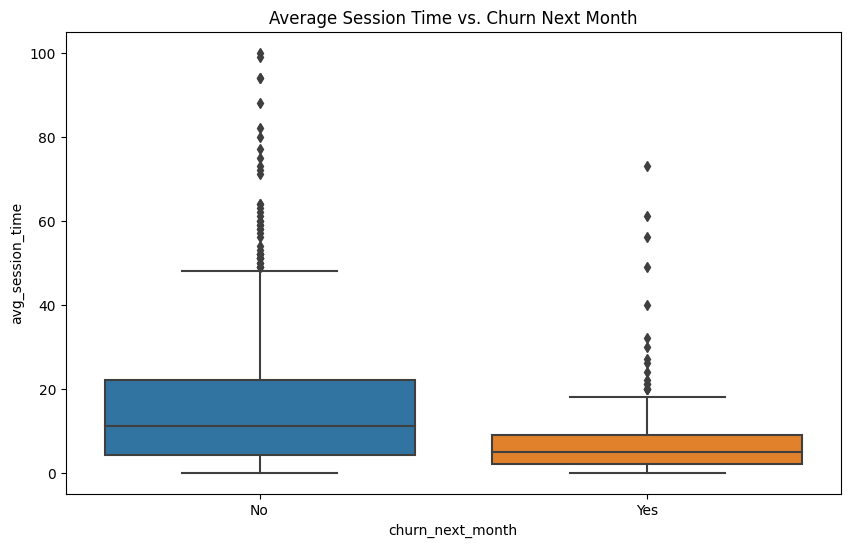

```python
# Box plot between avg_session_time and churn_numeric
plt.figure(figsize=(10, 6))
sns.boxplot(x='churn_next_month', y='avg_session_time', data=df_Info_data)
plt.title('Average Session Time vs. Churn Next Month')
plt.show()
```

### Step 4: Interpretation:

If executed, we might find a negative correlation indicating that the lower the average session time, the higher the likelihood of churn in the next month. The boxplot can further help visualize how the average session time is generally lower for users who churned compared to those who didn't. This information can be invaluable for the marketing team as it suggests that engaging users to spend more time on the platform could potentially reduce the churn rate.

## Question 3

**Scenario**: The analytics team has hypothesized that users who've applied to fewer jobs than average but have a higher number of posts shared might be influencers or thought leaders in their domain. However, there's also a belief that some of these users might be at risk of churning.

- Create a predictive model to determine if these users are likely to churn in the next month. Clearly state the target variable and its type. Assess the performance of your model.

  **Target Variable**: churn_next_month (Binary)

## Solution

### Hints:

1. **Data Exploration & Pre-processing**:
   - Understand the distribution of the target variable.
   - Identify missing values and handle them appropriately.
   - Feature engineering might be needed to capture the essence of the hypothesis.
2. **Feature Selection**:
   - The main features of interest are `job_applied` and `posts_shared`.
   - Other features can be added to the model based on their correlation or significance to the target variable.
   - Handling imbalanced data with SMOTE.
3. **Model Selection & Training**:
   - Since it's a binary classification problem, you can consider models like Logistic Regression, Random Forest, Gradient Boosting, etc. Here, we use Random Forest as the example.
   - Train the model on a subset of the data.
4. **Model Evaluation**:
   - Use metrics like accuracy, precision, recall, F1 score, and ROC-AUC to evaluate the model's performance on a validation set.
   - Feature Importance Evaluation.

### Step 1: Data Exploration & Pre-processing

```python
import pandas as pd

# Filter users based on hypothesis
average_jobs_applied = df_Info_data['job_applied'].mean()
df_filtered = df_Info_data[(df_Info_data['job_applied'] < average_jobs_applied) &
                           (df_Info_data['posts_shared'] > df_Info_data['posts_shared'].mean())]


# Check distribution of target variable
print(df_filtered['churn_next_month'].value_counts(normalize=True))

# Checking for missing values in Info_data
print(df_filtered.isnull().sum())

# Convert 'Yes' and 'No' values in the churn_next_month column to 1 and 0.
df_filtered['churn_next_month'] = df_filtered['churn_next_month'].map({'Yes': 1, 'No': 0})
```

```
No     0.864865
Yes    0.135135
Name: churn_next_month, dtype: float64
user_id                0
last_login             0
last_edited_profile    0
profile_views          0
posts_shared           0
connections_made       0
avg_session_time       0
job_applied            0
feedback_given         0
churn_next_month       0
churn_numeric          0
dtype: int64
```

Note: This indicates that 86.4% of the users did not churn, and only 13.6% of the users churned the next month. Such an imbalance might lead our model to be biased towards predicting the "No" class.

### Step 2: Feature Engineering and Data Balancing

```python
from imblearn.over_sampling import SMOTE
from sklearn.model_selection import train_test_split

# Define features and target variable
X = df_filtered.drop(['churn_next_month','churn_numeric'], axis=1)
y = df_filtered['churn_next_month']

# Identify Non-Numeric Features
print(X.select_dtypes(include=['object']).head())
```

```
     user_id feedback_given
0   eeed1652            Yes
5   df4d22f0             No
6   54aabedd             No
8   83f1989c             No
13  aa972f2e             No
```

```python
# Drop the user_id column as it's merely an identifier and will not aid in predictive modeling.
X = X.drop('user_id', axis=1)

# Convert the 'Yes' and 'No' values in the feedback_given column to 1 and 0 respectively.
X['feedback_given'] = X['feedback_given'].map({'Yes': 1, 'No': 0})

# Convert DateTime to Numerical Features
X['last_login_year'] = X['last_login'].dt.year
X['last_login_month'] = X['last_login'].dt.month
X['last_login_day'] = X['last_login'].dt.day

X['last_edited_year'] = X['last_edited_profile'].dt.year
X['last_edited_month'] = X['last_edited_profile'].dt.month
X['last_edited_day'] = X['last_edited_profile'].dt.day

# Drop original DateTime columns
X = X.drop(['last_login', 'last_edited_profile'], axis=1)

# Once you've handled the non-numeric features, you can try using SMOTE
smote = SMOTE(random_state=42)
X_resampled, y_resampled = smote.fit_resample(X, y)

# Splitting the Data:
X_train, X_test, y_train, y_test = train_test_split(X_resampled, y_resampled, test_size=0.3, random_state=42)
```

### Step 3: Model Selection & Training:

```python
from sklearn.ensemble import RandomForestClassifier

# Initialize Random Forest model
clf = RandomForestClassifier(random_state=42)
clf.fit(X_train, y_train)
```

```
RandomForestClassifier(random_state=42)
```

### Step 4: Model Evaluation:

```python
from sklearn.metrics import accuracy_score, precision_score, recall_score, f1_score, roc_auc_score

# Predictions
y_pred = clf.predict(X_test)

# Evaluation metrics
print(f"Accuracy: {accuracy_score(y_test, y_pred)}")
print(f"Precision: {precision_score(y_test, y_pred)}")
print(f"Recall: {recall_score(y_test, y_pred)}")
print(f"F1 Score: {f1_score(y_test, y_pred)}")
print(f"ROC-AUC: {roc_auc_score(y_test, clf.predict_proba(X_test)[:, 1])}")
```

```
Accuracy: 0.9482758620689655
Precision: 1.0
Recall: 0.8909090909090909
F1 Score: 0.9423076923076923
ROC-AUC: 0.9850968703427719
```

### Note:

**Model Performance**: The accuracy, precision, recall, and other metrics will give a holistic view of the model's performance. A high accuracy combined with high recall and precision is desirable.

**Improvements**: If the model's performance isn't satisfactory, consider including more features, hyperparameter tuning, or trying other classification algorithms. Always keep the business context in mind and consider the implications of false positives and false negatives in the churn prediction context.

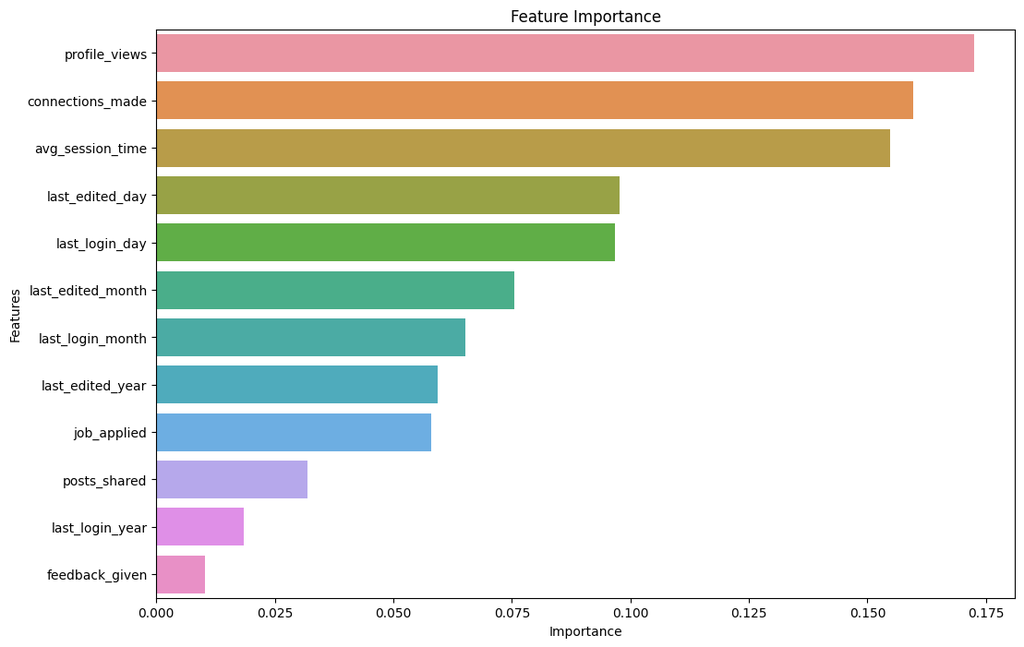

```python
import matplotlib.pyplot as plt
import seaborn as sns

# Get feature importances from the model
feature_importance = clf.feature_importances_

# Map features to their importance
feature_importance_dict = dict(zip(X.columns, feature_importance))

# Sort features based on importance
sorted_features = sorted(feature_importance_dict.items(), key=lambda x: x[1], reverse=True)

# Convert the sorted feature importance into separate lists for plotting
features, importances = zip(*sorted_features)

features_list = list(features)
importances_list = list(importances)

plt.figure(figsize=(12, 8))
sns.barplot(x=importances_list, y=features_list)
plt.title('Feature Importance')
plt.xlabel('Importance')
plt.ylabel('Features')
plt.show()
```

## Question 4

**Scenario**: LinkedIn wants to A/B test a new feature targeting users at risk of churning. They believe that showing more relevant job postings might increase engagement for users who have low `profile_views` but have shown interest in job postings by applying to some jobs.

- Design an A/B test to validate the impact of this new feature on user retention. What metrics will you monitor? And how will you analyze the results?

## Solution

### 1. **Experiment Design**:

#### A/B Testing:

- **Control Group (A)**: Users at risk of churning (low profile views and have applied to jobs) without the new feature.
- **Treatment Group (B)**: Users at risk of churning who are exposed to the new feature showcasing more relevant job postings.

We'd segregate users based on their profile views and job application behaviors. Then, we would randomly assign them to the two groups, ensuring an even distribution. This stratified random sampling helps control variables and reduces bias.

### 2. **Metrics to Measure**:

- **Primary Metric**: Retention Rate. By monitoring the churn_next_month column, we can determine if fewer users in Group B (exposed to the new feature) decided to leave the platform compared to Group A.
- **Secondary Metrics**:
  - Engagement: Monitor profile_views, posts_shared, connections_made, and avg_session_time. An increase in these metrics for Group B could suggest enhanced user engagement due to the feature.
  - Job Applications: If there's an increase in job_applied in Group B, it indicates the feature's relevance and success.
  - Feedback: Monitor feedback_given to gauge user satisfaction with the new feature.

### 3. **Duration of the Experiment**:

Given the monthly churn prediction timeframe, it's apt to run the experiment for at least a month. However, consider extending it if you haven't achieved statistical significance in observed differences.

### 4. **Analysis**:

- Use a Chi-square test to analyze differences in the churn rate between Groups A and B. A lower churn rate in Group B would suggest the new feature is beneficial.
- Use t-tests (or appropriate non-parametric tests depending on the data distribution) to compare secondary metrics like profile_views, job_applied, etc., between the two groups.

### 5. **Other Considerations**:

- **Segment Analysis**: Different user demographics or types might react differently. Consider segmenting users based on their activity levels, career levels (entry-level, mid-level, executive), or regions.
- **External Factors**: Are there any annual job fairs or hiring seasons during the testing period? Such events might affect job application behavior, so it's crucial to control or account for them.
- **Feedback Content**: Go beyond the binary feedback_given metric. Analyze feedback content to understand what specifically users liked or disliked about the new feature.

### 6. **Conclusion**:

If Group B showcases lower churn rates and higher engagement metrics, the new feature is a success, and LinkedIn should consider a full rollout. On the other hand, if the feature doesn't exhibit the desired impact, LinkedIn should gather insights from feedback and metrics to iterate on the feature. Continuous user behavior tracking will help in refining engagement strategies and curating a more personalized LinkedIn experience.